# Title Telomere Project Analysis_Cleaned Code

Dealing with missing clinical data: There are 26 missing birth weight values and 31 missing BW_SD, as some of the gestational ages are too low to calculate a SD. These cases were removed when fitting the model. I did not impute them as imputing would not take into account gestational age.

There were also 4 missing maternal ages. These were imputed, replacing the missing values with the median for maternal age.

Format my colours: Assigning specific colours to my groups, fetal sex, and IUGR status This just comes in handy when plotting these clinical variables. I don’t need to continuously define colours as I have done it in the beginning of the code.

**Start of Analysis**

Question 1: Are any of our confounding factors associated with telomere length? For this question I use only the control live born samples, as I want to know if there is an association within a normal population.

```r
CON<-T.Dat[which(T.Dat$GROUP=="CONTROL" & T.Dat$GA>24),]

##Maternal age (MA) vs TL
##Makes the plot- later displayed with all other plots
MA.TL<-ggplot(CON, aes(x = MA, y = TS)) +
 geom_point() +
 stat_smooth(method="lm",se=T) +
 theme_grey() +
   xlab("Maternal Age (years)") +
   ylab("T/S Ratio") +
   ggtitle("Change in Placental Telomere Length with Maternal Age ")

##Checking if there is a significant association between TL and MA. Does MA need to be included in our final model?
##Linear regression to determine if TL and MA are significantly associated
model_MA_effect<-lm(TS~MA, data = CON)
summary(model_MA_effect)##R=-0.0013, p=0.92
```

```
##
## Call:
## lm(formula = TS ~ MA, data = CON)
##
## Residuals:
##     Min      1Q  Median      3Q     Max
## -1.0844 -0.4202 -0.1284  0.1483  2.1798
##
## Coefficients:
##              Estimate Std. Error t value Pr(>|t|)
## (Intercept)  2.415402   0.463178   5.215 2.66e-06 ***
## MA          -0.001282   0.013923  -0.092    0.927
## ---
## Signif. codes:  0 '***' 0.001 '**' 0.01 '*' 0.05 '.' 0.1 ' ' 1
##
## Residual standard error: 0.6267 on 57 degrees of freedom
## Multiple R-squared:  0.0001488,  Adjusted R-squared:  -0.01739
## F-statistic: 0.008483 on 1 and 57 DF,  p-value: 0.9269
```

```r
##Maternal age is not significantly associated with telomere length

##Fetal Birth weight measured in standard deviation (BW_SD) vs TL
BW.TL<-ggplot(CON, aes(x = BW_SD, y = TS)) +
 geom_point() +
 stat_smooth(method="lm",se=T) +
 theme_grey() +
   xlab("Fetal Birth Weight (SD)") +
   ylab("T/S Ratio") +
   ggtitle("Change in Placental Telomere Length with Fetal Birth Weight (SD)")

##Checking if there is a significant association between TL and BW_SD. Does BW_SD need to be included in our final model?
##Linear regression to determine if TL and BW_SD are significantly associated
model_BW_SD_effect<-lm(TS~BW_SD, data = CON)
summary(model_BW_SD_effect)##-0.077, p=0.36
```

```
##
## Call:
## lm(formula = TS ~ BW_SD, data = CON)
##
## Residuals:
##     Min      1Q  Median      3Q     Max
## -1.0536 -0.3911 -0.1071  0.1933  2.1627
##
## Coefficients:
##             Estimate Std. Error t value Pr(>|t|)
## (Intercept)  2.41214    0.08737  27.609   <2e-16 ***
## BW_SD       -0.07726    0.08456  -0.914    0.365
## ---
## Signif. codes:  0 '***' 0.001 '**' 0.01 '*' 0.05 '.' 0.1 ' ' 1
##
## Residual standard error: 0.6282 on 55 degrees of freedom
##   (2 observations deleted due to missingness)
## Multiple R-squared:  0.01495,    Adjusted R-squared:  -0.00296
## F-statistic: 0.8347 on 1 and 55 DF,  p-value: 0.3649
```

```r
##Birth weight is not significantly associated with telomere length

##Gestational age (GA) vs TL
GA.TL<-ggplot(CON, aes(x = GA, y = TS)) +
 geom_point() +
 stat_smooth(method="lm",se=T) +
 theme_grey() +
   xlab("Gestational age (weeks)") +
   ylab("T/S Ratio") +
   ggtitle("Change in Placental Telomere Length with Gestational Age")

##Checking if there is a significant association between TL and GA. Does GA need to be included in our final model?
##Linear regression to determine if TL and GA are significantly associated
model_GA_effect<-lm(TS~GA, data = CON)
summary(model_GA_effect)##-0.041 p=0.019
```

```
##
## Call:
## lm(formula = TS ~ GA, data = CON)
##
## Residuals:
##      Min       1Q   Median       3Q      Max
## -1.27725 -0.42098 -0.01537  0.29944  1.89835
##
## Coefficients:
##             Estimate Std. Error t value Pr(>|t|)
## (Intercept)  3.75873    0.57976   6.483  2.3e-08 ***
## GA          -0.04117    0.01707  -2.411   0.0191 *
## ---
## Signif. codes:  0 '***' 0.001 '**' 0.01 '*' 0.05 '.' 0.1 ' ' 1
##
## Residual standard error: 0.5971 on 57 degrees of freedom
## Multiple R-squared:  0.09256,    Adjusted R-squared:  0.07664
## F-statistic: 5.814 on 1 and 57 DF,  p-value: 0.01914
```

```r
##GA is  significantly associated with telomere length

##Fetal Sex vs. TL
##Check to see if TS ratio is significantly different between males and females
Fe<-subset(CON,SEX=="FEMALE")
rownames(Fe)<-Fe$Sample
Fe<-Fe[,5]

Male<-subset(CON,SEX=="MALE")
rownames(Male)<-Male$Sample
Male<-Male[,5]

t.test(Male,Fe)##p=0.0037
```

```
##
##  Welch Two Sample t-test
##
## data:  Male and Fe
## t = -3.0657, df = 42.422, p-value = 0.003769
## alternative hypothesis: true difference in means is not equal to 0
## 95 percent confidence interval:
##  -0.7962365 -0.1641982
## sample estimates:
## mean of x mean of y
##  2.153648  2.633865
```

```r
##Significant difference

##But is Fetal sex singificantly different when we account for gestational age?
SexvTS<- ggplot(CON, aes(SEX, TS)) +
   geom_boxplot()+scale_fill_manual(values=unique(sex.col))+
  guides(fill=FALSE)+
   theme_grey() +
   xlab("Fetal Sex") +
   ylab("T/S Ratio") +
   ggtitle("Change in Placental Telomere Length with Fetal Sex")

##Checking if there is a significant association between TL and Fetal Sex. Does Fetal Sex need to be included in our final model?
##Linear regression to determine if TL differs between sex taking into account gestational age
model_GA_effect<-lm(TS~SEX+GA, data = CON)
summary(model_GA_effect)##r=-0.43, p=0.001
```

```
##
## Call:
## lm(formula = TS ~ SEX + GA, data = CON)
##
## Residuals:
##      Min       1Q   Median       3Q      Max
## -1.06314 -0.28315 -0.05372  0.23302  1.70338
##
## Coefficients:
##             Estimate Std. Error t value Pr(>|t|)
## (Intercept)  3.78807    0.54361   6.968  3.9e-09 ***
## SEXMALE     -0.43895    0.14751  -2.976  0.00431 **
## GA          -0.03497    0.01614  -2.166  0.03457 *
## ---
## Signif. codes:  0 '***' 0.001 '**' 0.01 '*' 0.05 '.' 0.1 ' ' 1
##
## Residual standard error: 0.5598 on 56 degrees of freedom
## Multiple R-squared:  0.2165, Adjusted R-squared:  0.1885
## F-statistic: 7.735 on 2 and 56 DF,  p-value: 0.001081
```

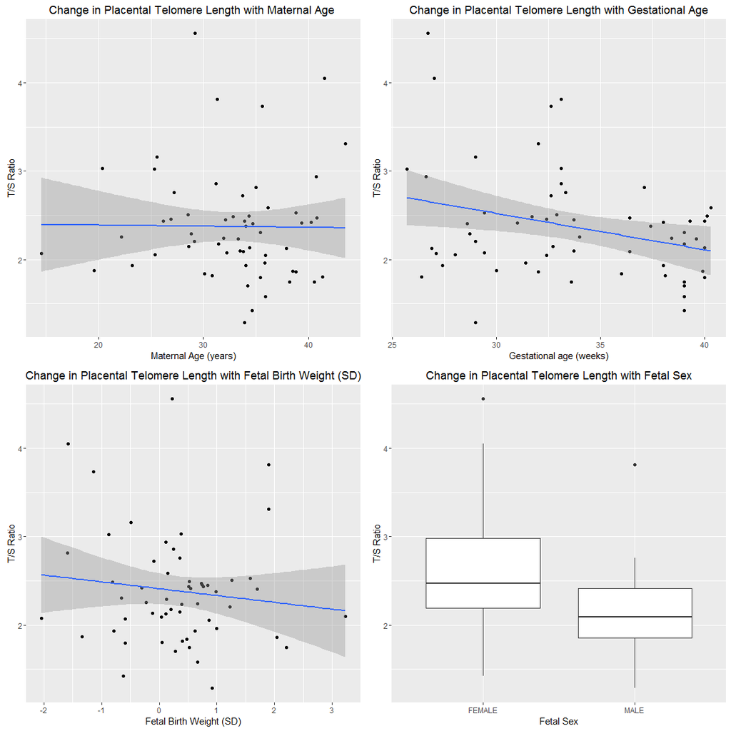

```r
##Fetal sex is significantly associated with telomere length, even when you take into account GA

##Putting all graphs in one fig
grid.arrange(MA.TL,GA.TL,BW.TL,SexvTS,ncol=2)
```

One question the comes out of question 1 is whether gestational age at delivery differs between males and female fetuses?

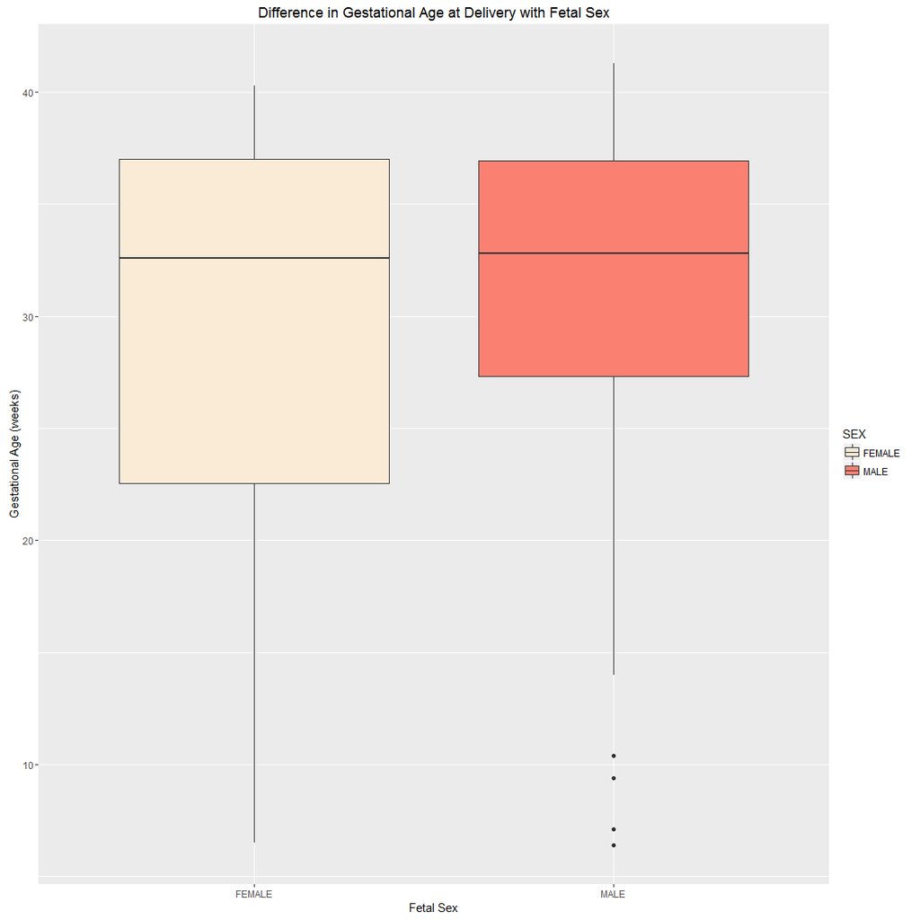

```r
##Fetal Sex vs. TL
(SexvGA<- ggplot(T.Dat, aes(SEX, GA,fill=SEX)) +
   geom_boxplot()+scale_fill_manual(values=unique(sex.col)))+
   theme_grey() +
   xlab("Fetal Sex") +
   ylab("Gestational Age (weeks)") +
   ggtitle("Difference in Gestational Age at Delivery with Fetal Sex")
```

```r
##Check to see is gestational age is significantly different between males and females
Fe<-subset(T.Dat,SEX=="FEMALE")
rownames(Fe)<-Fe$Sample
Fe<-Fe[,10]

Male<-subset(T.Dat,SEX=="MALE")
rownames(Male)<-Male$Sample
Male<-Male[,10]

t.test(Male,Fe)
```

```
##
##  Welch Two Sample t-test
##
## data:  Male and Fe
## t = 1.1714, df = 132.44, p-value = 0.2436
## alternative hypothesis: true difference in means is not equal to 0
## 95 percent confidence interval:
##  -1.305599  5.097266
## sample estimates:
## mean of x mean of y
##  30.44583  28.55000
```

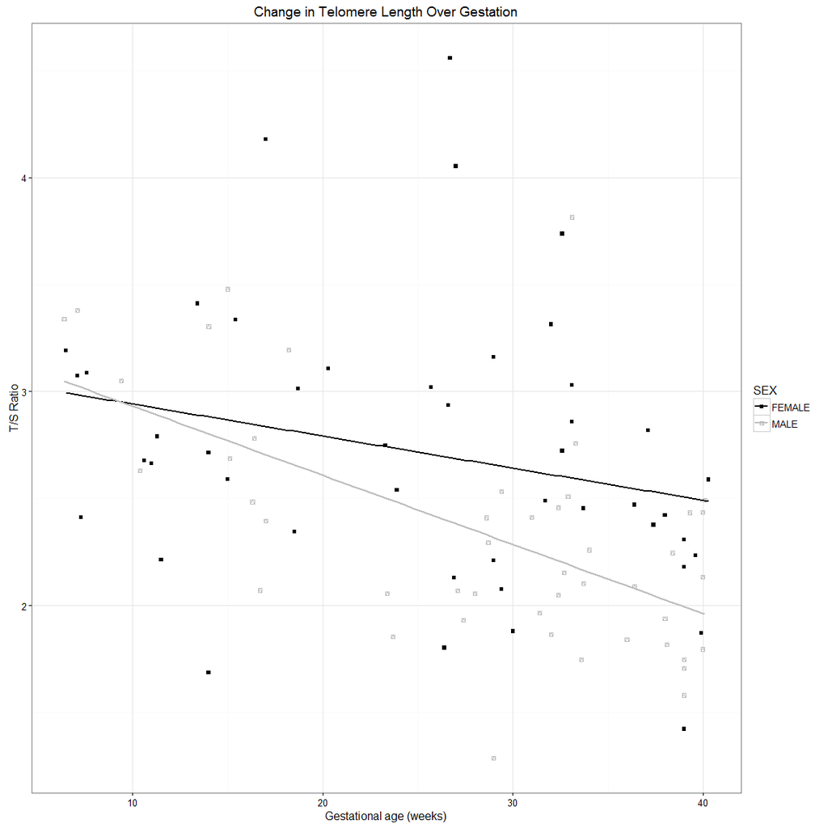

```r
##No significant difference

##Taking into account gestational age, do we still see a difference in TL between male and female fetuses using all the controls across gestationa age, not just the live born?
ALL.CON<-T.Dat[which(T.Dat$GROUP=="CONTROL"),]
ggplot(ALL.CON, aes(x = GA, y = TS,color=SEX,shape=SEX)) +
geom_point() + scale_color_manual(values = c("FEMALE" = 'black','MALE' = 'grey')) +
scale_shape_manual(values = c('FEMALE' = 15, 'MALE' = 14))+
 stat_smooth(method="lm",se=F) +
 theme_bw() +
   xlab("Gestational age (weeks)") +
   ylab("T/S Ratio") +
   ggtitle("Change in Telomere Length Over Gestation")
```

```r
##Checking to see if the TL distributiuons are significantly different
Fe<-subset(T.Dat,SEX=="FEMALE")
rownames(Fe)<-Fe$Sample
Fe<-Fe[,5]

Male<-subset(T.Dat,SEX=="MALE")
rownames(Male)<-Male$Sample
Male<-Male[,5]

ks_test2<-ks.test(Fe,Male, alternative=c("two.sided"),exact=T)
print(ks_test2)
```

```
##
##  Two-sample Kolmogorov-Smirnov test
##
## data:  Fe and Male
## D = 0.27288, p-value = 0.008379
## alternative hypothesis: two-sided
```

```r
##Significantly Different

##Comparing the linear regression lines between male and females
Fe<-subset(T.Dat,SEX=="FEMALE" & GROUP=="CONTROL")
rownames(Fe)<-Fe$Sample
model_Fe<-lm(TS~GA, data = Fe)##Sex not in model as this is being done seperately
summary(model_Fe)##GA, p=0.09
```

```
##
## Call:
## lm(formula = TS ~ GA, data = Fe)
##
## Residuals:
##     Min      1Q  Median      3Q     Max
## -1.1962 -0.3148 -0.1136  0.2766  1.8659
##
## Coefficients:
##             Estimate Std. Error t value Pr(>|t|)
## (Intercept)  3.09208    0.23806  12.989   <2e-16 ***
## GA          -0.01499    0.00872  -1.719   0.0926 .
## ---
## Signif. codes:  0 '***' 0.001 '**' 0.01 '*' 0.05 '.' 0.1 ' ' 1
##
## Residual standard error: 0.6261 on 44 degrees of freedom
## Multiple R-squared:  0.06293,    Adjusted R-squared:  0.04164
## F-statistic: 2.955 on 1 and 44 DF,  p-value: 0.09264
```

```r
Male<-subset(T.Dat,SEX=="MALE"& GROUP=="CONTROL")
rownames(Male)<-Male$Sample
model_M<-lm(TS~GA, data = Male)##Sex not in model as this is being done seperately
summary(model_M)##GA, p=1.6e-05
```

```
##
## Call:
## lm(formula = TS ~ GA, data = Male)
##
## Residuals:
##      Min       1Q   Median       3Q      Max
## -1.03034 -0.28864 -0.05534  0.24474  1.62861
##
## Coefficients:
##              Estimate Std. Error t value Pr(>|t|)
## (Intercept)  3.254391   0.200036  16.269  < 2e-16 ***
## GA          -0.032295   0.006664  -4.846  1.6e-05 ***
## ---
## Signif. codes:  0 '***' 0.001 '**' 0.01 '*' 0.05 '.' 0.1 ' ' 1
##
## Residual standard error: 0.4488 on 44 degrees of freedom
## Multiple R-squared:  0.348,  Adjusted R-squared:  0.3332
## F-statistic: 23.49 on 1 and 44 DF,  p-value: 1.599e-05
```

```r
##are these linear regression models significantly different
s1 <- summary(model_Fe)$coefficients
s2 <- summary(model_M)$coefficients
db <- (s2[2,1]-s1[2,1])
sd <- sqrt(s2[2,2]^2+s1[2,2]^2)
df <- (model_Fe$df.residual+model_M$df.residual)
td <- db/sd
2*pt(-abs(td), df)
```

```
## [1] 0.1184088
```

```r
##p=0.12 trend that the male and female controls have significantly different rates of TL decline
```

Question 2: Does telomere legnth differ between EOPE,LOPE, and IUGR compared to controls? What about between one another?

```r
##Removing the non-viable control samples, those <24wks
rm<-T.Dat[which(T.Dat$GROUP=="CONTROL" & T.Dat$GA<24),]
T.Dat<-T.Dat[-which(rownames(T.Dat) %in% rownames(rm)),]

##This leaves us with a sample set of:
print(table(T.Dat$GROUP))##59 controls
```

```
##
## CONTROL    EOPE    IUGR    LOPE
##      59      21       9      18
```

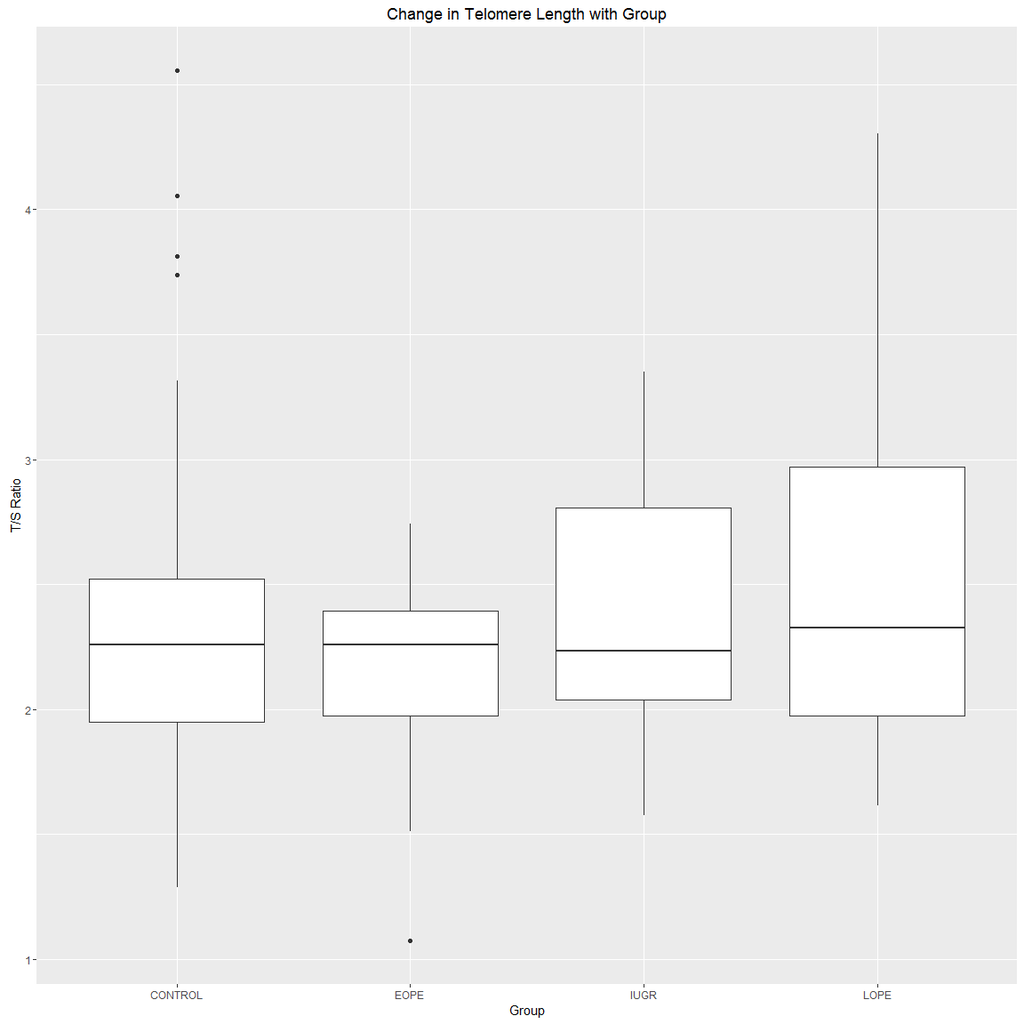

```r
##Plot Telomere length between Groups
(GRPvTS<- ggplot(T.Dat, aes(GROUP, TS)) +
   geom_boxplot()+scale_fill_manual(values=unique(grp.col)))+
   theme_grey() +
   xlab("Group") +
   ylab("T/S Ratio") +
   ggtitle("Change in Telomere Length with Group")
```

```r
TL_Model<-lm(TS~GROUP+SEX+GA, data = T.Dat)
summary(TL_Model)
```

```
##
## Call:
## lm(formula = TS ~ GROUP + SEX + GA, data = T.Dat)
##
## Residuals:
##      Min       1Q   Median       3Q      Max
## -1.20385 -0.40707 -0.05035  0.29082  1.84010
##
## Coefficients:
##             Estimate Std. Error t value Pr(>|t|)
## (Intercept)  3.44365    0.50858   6.771 8.59e-10 ***
## GROUPEOPE   -0.25112    0.15137  -1.659   0.1002
## GROUPIUGR    0.04948    0.21488   0.230   0.8183
## GROUPLOPE    0.23155    0.16726   1.384   0.1693
## SEXMALE     -0.28652    0.11402  -2.513   0.0136 *
## GA          -0.02719    0.01491  -1.823   0.0712 .
## ---
## Signif. codes:  0 '***' 0.001 '**' 0.01 '*' 0.05 '.' 0.1 ' ' 1
##
## Residual standard error: 0.5844 on 101 degrees of freedom
## Multiple R-squared:  0.1219, Adjusted R-squared:  0.07845
## F-statistic: 2.805 on 5 and 101 DF,  p-value: 0.02053
```

```r
##ANOVA is used to compare telomere length between all of our pathology groups
amod <- aov(TS~GROUP+SEX+GA, data = T.Dat)
cht <- glht(amod, linfct = mcp(GROUP = "Tukey"))

summary(cht, test = univariate())
```

```
##
##   Simultaneous Tests for General Linear Hypotheses
##
## Multiple Comparisons of Means: Tukey Contrasts
##
##
## Fit: aov(formula = TS ~ GROUP + SEX + GA, data = T.Dat)
##
## Linear Hypotheses:
##                     Estimate Std. Error t value Pr(>|t|)
## EOPE - CONTROL == 0 -0.25112    0.15137  -1.659   0.1002
## IUGR - CONTROL == 0  0.04948    0.21488   0.230   0.8183
## LOPE - CONTROL == 0  0.23155    0.16726   1.384   0.1693
## IUGR - EOPE == 0     0.30061    0.24579   1.223   0.2242
## LOPE - EOPE == 0     0.48267    0.20633   2.339   0.0213 *
## LOPE - IUGR == 0     0.18206    0.23880   0.762   0.4476
## ---
## Signif. codes:  0 '***' 0.001 '**' 0.01 '*' 0.05 '.' 0.1 ' ' 1
## (Univariate p values reported)
```

```r
##No significant difference in TL between pathology and controls, although a significant difference in TL between EOPE and LOPE
```

Question 4.Is TL associated with genome wide changes in DNAm? ##I am loading in already pre-processed data from another project looking at changes in DNAm in EOPE,LOPE, and IUGR and assessing the relationship between these pathologies. The scripts for the preprocessing will be uploaded seperately.

```r
load('AnalysisReadyData.RData')

##Make new project containing only the samples for which telomere length was measured
PROJECT<-Data[, which(colnames(Data)  %in% rownames(T.Dat))]
dim(PROJECT)##58 samples
```

```
## [1] 441093     58
```

```r
colnames(PROJECT)  %in% rownames(T.Dat)
```

```
##  [1] TRUE TRUE TRUE TRUE TRUE TRUE TRUE TRUE TRUE TRUE TRUE TRUE TRUE TRUE
## [15] TRUE TRUE TRUE TRUE TRUE TRUE TRUE TRUE TRUE TRUE TRUE TRUE TRUE TRUE
## [29] TRUE TRUE TRUE TRUE TRUE TRUE TRUE TRUE TRUE TRUE TRUE TRUE TRUE TRUE
## [43] TRUE TRUE TRUE TRUE TRUE TRUE TRUE TRUE TRUE TRUE TRUE TRUE TRUE TRUE
## [57] TRUE TRUE
```

```r
Des<-T.Dat[which(rownames(T.Dat) %in% colnames(Data)),]
Des$Sample<-droplevels(Des$Sample)

##Ordering the Project (DNAm data) in the same order as the meta data
PROJECT <- PROJECT[,order(colnames(PROJECT))]
Des<-Des[order(rownames(Des)),]
rownames(Des)==colnames(PROJECT)
```

```
##  [1] TRUE TRUE TRUE TRUE TRUE TRUE TRUE TRUE TRUE TRUE TRUE TRUE TRUE TRUE
## [15] TRUE TRUE TRUE TRUE TRUE TRUE TRUE TRUE TRUE TRUE TRUE TRUE TRUE TRUE
## [29] TRUE TRUE TRUE TRUE TRUE TRUE TRUE TRUE TRUE TRUE TRUE TRUE TRUE TRUE
## [43] TRUE TRUE TRUE TRUE TRUE TRUE TRUE TRUE TRUE TRUE TRUE TRUE TRUE TRUE
## [57] TRUE TRUE
```

```r
dim(PROJECT)
```

```
## [1] 441093     58
```

```r
##save PROJECT
##save(PROJECT,file="PROJECT.Telomere.Final.DNAm_Data.RData")
```

Question 3. Do we see changes in DNAm specifically at TERC,TERT,DNMTs or TERRA associated with telomere length? Not correcting for group as if was not significantly different in our data

```r
##TERF2
load('FeatureData.RData')##This is an annotation for Price et al 2013


##TERC- Pulling all probes that are annotated to the TERC gene
TERCprobes<-fData[which(fData$Closest_TSS_gene_name=="TERC"),]##15probes
TERC.PROJECT<-PROJECT[which(rownames(PROJECT) %in% rownames(TERCprobes)),]
dim(TERC.PROJECT)##15 probes by 58 samples
```

```
## [1] 15 58
```

```r
##Linear model looking for associated between DNAm within TERC and TL
DesMat.TERC<- model.matrix(~TS+GA+SEX,Des)

##Pull out m-values
mDat.TERC<-TERC.PROJECT
str(mDat.TERC)
```

```
##  num [1:15, 1:58] 1.327 1.041 -2.778 -1.063 0.133 ...
##  - attr(*, "dimnames")=List of 2
##   ..$ : chr [1:15] "cg00151728" "cg00759573" "cg01389761" "cg07774096" ...
##   ..$ : chr [1:58] "PL104" "PL112" "PL130" "PL131" ...
```

```r
Fit.TERC<- lmFit(mDat.TERC, DesMat.TERC)
EbFit.TERC <- eBayes(Fit.TERC)
print(topTable(EbFit.TERC,coef="TS"))
```

```
##                  logFC    AveExpr          t   P.Value adj.P.Val         B
## cg16529676 -0.09356091 -0.8933607 -1.3771257 0.1737063 0.7029839 -4.476307
## cg07774096  0.11751694 -1.2838447  1.2150992 0.2291967 0.7029839 -4.589319
## cg00759573  0.13436856  0.1352174  1.0461699 0.2997746 0.7029839 -4.693105
## cg15494117  0.19244182 -5.6013905  1.0188335 0.3124659 0.7029839 -4.708524
## cg18507362 -0.05737213  3.7670873 -0.9801218 0.3310513 0.7029839 -4.729695
## cg00151728  0.08942605  0.7962726  0.9257934 0.3583467 0.7029839 -4.758087
## cg27020690  0.13066182 -3.7518437  0.8060717 0.4234575 0.7029839 -4.815154
## cg25090302  0.04668700  2.7514534  0.7852463 0.4354694 0.7029839 -4.824302
## cg15599946  0.10600648 -5.5831834  0.7259461 0.4707585 0.7029839 -4.849077
## cg12615982  0.05200292 -0.7642818  0.6241009 0.5349812 0.7029839 -4.887195
```

```r
## No significant association

##TERT- Pulling all probes that are annotated to the TERT gene
TERTprobes<-fData[which(fData$Closest_TSS_gene_name=="TERT"),]##99probes
TERT.PROJECT<-PROJECT[which(rownames(PROJECT) %in% rownames(TERTprobes)),]
dim(TERT.PROJECT)##99 probes by 58 samples
```

```
## [1] 99 58
```

```r
##Linear model looking for associated between DNAm within TERT and TL
DesMat.TERT<- model.matrix(~TS+GA+SEX,Des)

##Pull out m-values
mDat.TERT<-TERT.PROJECT
Fit.TERT<- lmFit(mDat.TERT, DesMat.TERT)
EbFit.TERT <- eBayes(Fit.TERT)
tt_TERT<-topTable(EbFit.TERT,coef="TS",n=99)
print(head(tt_TERT))
```

```
##                logFC    AveExpr        t      P.Value   adj.P.Val
## cg01934390 0.3188076 -0.5575195 4.542546 2.769683e-05 0.002741986
## cg08934976 0.3924597  3.2218087 4.101241 1.266377e-04 0.006268567
## cg10878976 0.2819884 -0.3706408 3.921434 2.304417e-04 0.007604575
## cg07728485 0.3735151  2.0583525 3.778885 3.669390e-04 0.009081740
## cg11832804 0.4729484  1.8346080 3.521889 8.298522e-04 0.013811261
## cg08295072 0.3066446  1.9416284 3.519118 8.370461e-04 0.013811261
##                     B
## cg01934390  2.2799074
## cg08934976  0.8481978
## cg10878976  0.2874839
## cg07728485 -0.1466778
## cg11832804 -0.9044054
## cg08295072 -0.9123902
```

```r
##significant association top 16 probes

##Saving this information to construct figure 4 of the paper
##write.table(tt_TERT,file="TERT_pvals.txt")
##Run the beta values through the model to look at the magnitude of change in DNAm
TERT.PROJECT.betas<-m2beta(TERT.PROJECT)
Fit.TERT<- lmFit(TERT.PROJECT.betas, DesMat.TERT)
EbFit.TERT <- eBayes(Fit.TERT)
tt_TERT_betas<-topTable(EbFit.TERT,coef="TS",n=99)
head(tt_TERT_betas)
```

```
##                 logFC   AveExpr        t      P.Value   adj.P.Val
## cg01934390 0.05284670 0.4057200 4.634652 0.0000213059 0.002109284
## cg10878976 0.04749427 0.4369568 3.997838 0.0001861920 0.009216504
## cg08934976 0.02442186 0.9000194 3.776625 0.0003820192 0.012606633
## cg07728485 0.03851322 0.8020095 3.605927 0.0006559634 0.016235094
## cg08295072 0.03542864 0.7902303 3.465951 0.0010120615 0.017151444
## cg19977628 0.04953560 0.5632722 3.457225 0.0010394814 0.017151444
##                      B
## cg01934390  2.14191170
## cg10878976  0.05725549
## cg08934976 -0.62764308
## cg07728485 -1.14018872
## cg08295072 -1.54938101
## cg19977628 -1.57454533
```

```r
MAP<-TERTprobes[,c("MAPINF0-1")]
tt_TERT_betas<-cbind(tt_TERT_betas,MAP)
##write.table(tt_TERT_betas,file="tt_TERT_betas.txt")

##DNMT1
DNMT1probes<-fData[which(fData$Closest_TSS_gene_name=="DNMT1"),]##19probes
DNMT1.PROJECT<-PROJECT[which(rownames(PROJECT) %in% rownames(DNMT1probes)),]
dim(DNMT1.PROJECT)##19 probes by 58 samples
```

```
## [1] 19 58
```

```r
##Linear model looking for associated between DNAm within DNMT1 and TL
DesMat.DNMT1<- model.matrix(~TS+GA+SEX,Des)

##Pull out m-values
mDat.DNMT1<-DNMT1.PROJECT
Fit.DNMT1<- lmFit(mDat.DNMT1, DesMat.DNMT1)
EbFit.DNMT1 <- eBayes(Fit.DNMT1)
topTable(EbFit.DNMT1,coef="TS",n=20)
```

```
##                   logFC     AveExpr          t      P.Value   adj.P.Val
## cg07627628  0.255151527  0.06747306  3.7756770 0.0003732757 0.007092239
## cg26538782 -0.342606150  2.06898670 -3.0800805 0.0031419714 0.029848728
## cg17445987 -0.103987609  0.16229229 -2.5610109 0.0130173051 0.082442932
## cg16260438  0.147326430  2.15705462  2.1608614 0.0347816898 0.165213027
## cg12053136  0.153292395  3.47997602  1.8342434 0.0716674634 0.236208774
## cg26705765  0.161085878  4.64429953  1.8157005 0.0745922445 0.236208774
## cg19803081  0.137383702 -0.42212560  1.7172861 0.0911780326 0.247483231
## cg09445675 -0.118808245  3.36043255 -1.5404587 0.1288010086 0.305902395
## cg10635912 -0.071043557 -0.31663087 -1.4208584 0.1606273881 0.324643449
## cg21063296  0.079521320 -0.94239813  1.3863421 0.1708649732 0.324643449
## cg08326996  0.057327931 -0.69369075  1.2361598 0.2213032890 0.382251136
## cg23662947  0.060882605  4.37894266  1.0566111 0.2950010527 0.462334206
## cg07955051  0.042933319 -0.51139890  0.9828576 0.3296952198 0.462334206
## cg24477899 -0.039061474 -0.07066082 -0.9606212 0.3406673097 0.462334206
## cg15043801 -0.040700748 -0.82096578 -0.7529918 0.4544522517 0.575639519
## cg06128182 -0.024388044 -0.51619688 -0.4610384 0.6464972209 0.750234057
## cg01347596  0.028440374  2.62575776  0.4265488 0.6712620509 0.750234057
## cg21892967 -0.012209262 -1.15133562 -0.2235917 0.8238482829 0.834192443
## cg23401624  0.005771966  0.31884127  0.2102568 0.8341924428 0.834192443
##                      B
## cg07627628 -0.04435589
## cg26538782 -1.98314877
## cg17445987 -3.24444915
## cg16260438 -4.08978131
## cg12053136 -4.68890343
## cg26705765 -4.71768304
## cg19803081 -4.88234988
## cg09445675 -5.15286339
## cg10635912 -5.32049030
## cg21063296 -5.36652477
## cg08326996 -5.55442838
## cg23662947 -5.75218700
## cg07955051 -5.82479595
## cg24477899 -5.84569182
## cg15043801 -6.01832208
## cg06128182 -6.18817305
## cg01347596 -6.20635360
## cg21892967 -6.27107994
## cg23401624 -6.27392126
```

```r
##significant association in top 2 probes

DNMT1.PROJECT.betas<-m2beta(DNMT1.PROJECT)
Fit.DNMT1<- lmFit(DNMT1.PROJECT.betas, DesMat.DNMT1)
EbFit.DNMT1 <- eBayes(Fit.DNMT1)
tt_DNMT1_betas<-topTable(EbFit.DNMT1,coef="TS",n=19)
print(head(tt_DNMT1_betas))
```

```
##                  logFC   AveExpr         t      P.Value   adj.P.Val
## cg07627628  0.04325552 0.5113869  3.767138 0.0003950448 0.007505852
## cg26538782 -0.04352793 0.8017668 -3.049753 0.0034790533 0.033051006
## cg17445987 -0.01794763 0.5280246 -2.671053 0.0098520534 0.062396338
## cg16260438  0.01454300 0.8151037  2.021683 0.0479402522 0.227716198
## cg19803081  0.02291098 0.4283363  1.731101 0.0888752827 0.336216214
## cg12053136  0.00790501 0.9159625  1.626891 0.1093083690 0.336216214
##                    B
## cg07627628 -1.093275
## cg26538782 -3.148051
## cg17445987 -4.107689
## cg16260438 -5.514335
## cg19803081 -6.034968
## cg12053136 -6.204062
```

```r
MAP<-DNMT1probes[,c("MAPINF0-1")]
tt_DNMT1_betas<-cbind(tt_DNMT1_betas,MAP)
##write.table(tt_DNMT1_betas,file="tt_DNMT1_betas.txt")

##DNMT3a
DNMT3Aprobes<-fData[which(fData$Closest_TSS_gene_name=="DNMT3A"),]##88probes
DNMT3A.PROJECT<-PROJECT[which(rownames(PROJECT) %in% rownames(DNMT3Aprobes)),]
dim(DNMT3A.PROJECT)##88 probes by 58 samples
```

```
## [1] 88 58
```

```r
##Linear model looking for associated between DNAm within DNMT3a and TL
DesMat.DNMT3A<- model.matrix(~TS+GA+SEX,Des)

##Pull out m-values
mDat.DNMT3A<-DNMT3A.PROJECT
Fit.DNMT3A<- lmFit(mDat.DNMT3A, DesMat.DNMT3A)
EbFit.DNMT3A <- eBayes(Fit.DNMT3A)
topTable(EbFit.DNMT3A,coef="TS",n=20)
```

```
##                  logFC    AveExpr         t      P.Value  adj.P.Val
## cg11779362  0.30097902  0.3544979  4.405277 4.456943e-05 0.00392211
## cg08485187 -0.22908958  1.2824847 -3.763955 3.840731e-04 0.01689922
## cg13558695 -0.22835232  1.0446770 -2.868150 5.727925e-03 0.16801914
## cg23009818 -0.14445132  1.4112311 -2.668002 9.809158e-03 0.21580147
## cg17742416 -0.14830004  1.8712417 -2.447437 1.739949e-02 0.22720360
## cg20669908 -0.09847272  0.7240633 -2.405301 1.927611e-02 0.22720360
## cg03980035 -0.23023175  1.3524988 -2.273964 2.657807e-02 0.22720360
## cg00886730 -0.11952478  3.3642335 -2.254722 2.789627e-02 0.22720360
## cg03208817 -0.11545444 -4.4095689 -2.195062 3.205971e-02 0.22720360
## cg23569120  0.12609368  5.1964554  2.175942 3.352913e-02 0.22720360
## cg05896193 -0.13240801  1.7168755 -2.163531 3.451424e-02 0.22720360
## cg00856404 -0.09646166  0.7259135 -2.144482 3.614603e-02 0.22720360
## cg18889183 -0.10656673 -6.2879527 -2.145173 3.601787e-02 0.22720360
## cg23733525 -0.09831314 -5.3886058 -2.143811 3.613165e-02 0.22720360
## cg23200404 -0.08990158  3.6967113 -2.098964 4.005855e-02 0.23501018
## cg05529848 -0.11559606 -5.4980439 -1.972879 5.314580e-02 0.29230190
## cg15998962 -0.08742822 -4.2188155 -1.837200 7.124473e-02 0.36879624
## cg10749994  0.23510815 -3.6442241  1.778946 8.034042e-02 0.37377679
## cg26470599  0.12062688  2.4651523  1.776769 8.070181e-02 0.37377679
## cg11798660 -0.30457241  2.3386262 -1.725018 8.969892e-02 0.39467524
##                     B
## cg11779362  1.8482230
## cg08485187 -0.1674793
## cg13558695 -2.6324692
## cg23009818 -3.1251485
## cg17742416 -3.6274736
## cg20669908 -3.7202930
## cg03980035 -3.9989278
## cg00886730 -4.0393110
## cg03208817 -4.1600251
## cg23569120 -4.1983399
## cg05896193 -4.2230575
## cg00856404 -4.2585430
## cg18889183 -4.2593989
## cg23733525 -4.2620841
## cg23200404 -4.3497007
## cg05529848 -4.5874420
## cg15998962 -4.8255336
## cg10749994 -4.9277721
## cg26470599 -4.9314144
## cg11798660 -5.0168189
```

```r
##significant association in top 2 probes

DNMT3A.PROJECT.betas<-m2beta(DNMT3A.PROJECT)
Fit.DNMT3A<- lmFit(DNMT3A.PROJECT.betas, DesMat.DNMT3A)
EbFit.DNMT3A<- eBayes(Fit.DNMT3A)
tt_DNMT3A_betas<-topTable(EbFit.DNMT3A,coef="TS",n=88)
print(head(tt_DNMT3A_betas))
```

```
##                  logFC   AveExpr         t      P.Value   adj.P.Val
## cg11779362  0.05056775 0.5602847  4.322534 6.514219e-05 0.005732513
## cg08485187 -0.03273834 0.7071495 -3.820844 3.400984e-04 0.014964327
## cg13558695 -0.03346007 0.6713793 -2.785527 7.352397e-03 0.215502518
## cg23009818 -0.01936470 0.7255968 -2.675902 9.795569e-03 0.215502518
## cg20669908 -0.01587941 0.6225418 -2.531230 1.425008e-02 0.234833138
## cg17742416 -0.01721966 0.7838695 -2.400298 1.985211e-02 0.234833138
##                     B
## cg11779362 -0.3287541
## cg08485187 -1.9256862
## cg13558695 -4.8115479
## cg23009818 -5.0897959
## cg20669908 -5.4311055
## cg17742416 -5.7259182
```

```r
MAP<-DNMT3Aprobes[,c("MAPINF0-1")]
tt_DNMT3A_betas<-cbind(tt_DNMT3A_betas,MAP)
##write.table(tt_DNMT3A_betas,file="tt_DNMT3A_betas.txt")

##DNMT3b
DNMT3Bprobes<-fData[which(fData$Closest_TSS_gene_name=="DNMT3B"),]##21probes
DNMT3B.PROJECT<-PROJECT[which(rownames(PROJECT) %in% rownames(DNMT3Bprobes)),]
dim(DNMT3B.PROJECT)##21 probes by 58 samples
```

```
## [1] 21 58
```

```r
##Linear model looking for associated between DNAm within DNMT3b and TL
DesMat.DNMT3B<- model.matrix(~TS+GA+SEX,Des)

##Pull out m-values
mDat.DNMT3B<-DNMT3B.PROJECT
Fit.DNMT3B<- lmFit(mDat.DNMT3B, DesMat.DNMT3B)
EbFit.DNMT3B <- eBayes(Fit.DNMT3B)
topTable(EbFit.DNMT3B,coef="TS",n=20)
```

```
##                  logFC    AveExpr          t    P.Value adj.P.Val
## cg09149842 -0.12877270 -5.1304441 -2.6494963 0.01031441 0.2166026
## cg09835408 -0.10119243  1.2349361 -1.9524714 0.05560219 0.4560972
## cg00300969  0.07957616 -0.5943727  1.8789940 0.06515675 0.4560972
## cg22605822 -0.07838101  1.5302526 -1.6065556 0.11345796 0.4983106
## cg01243992 -0.10287530  3.4243203 -1.5833903 0.11864539 0.4983106
## cg01870247 -0.07320824  2.5001964 -1.2814922 0.20500324 0.5615724
## cg13636640  0.22615324 -2.6343579  1.2238628 0.22583877 0.5615724
## cg16523653 -0.04454379 -6.2031276 -1.2041888 0.23329547 0.5615724
## cg25803642  0.06230285 -4.8866324  1.1228684 0.26601368 0.5615724
## cg14224313  0.07727946  2.7424789  1.0788733 0.28500792 0.5615724
## cg24403338  0.05074989 -0.9097690  0.9933341 0.32457844 0.5615724
## cg14320358 -0.03997331  3.5433431 -0.9263426 0.35801831 0.5615724
## cg13788819 -0.05356743  1.3318498 -0.8698225 0.38790054 0.5615724
## cg17475857  0.04286113 -0.7270435  0.8532631 0.39694279 0.5615724
## cg16953106 -0.04959065 -6.0140255 -0.8456866 0.40112311 0.5615724
## cg22052056 -0.03051579  3.6047905 -0.6235734 0.53529622 0.6657252
## cg08554061 -0.03033125  3.1340718 -0.5909196 0.55681732 0.6657252
## cg21235334  0.03865512 -3.1400293  0.5703616 0.57062158 0.6657252
## cg17721173 -0.02212232 -5.3017731 -0.5040477 0.61609330 0.6809452
## cg17482740  0.01521564 -1.0802595  0.3358063 0.73820082 0.7751109
##                    B
## cg09149842 -2.703754
## cg09835408 -3.941590
## cg00300969 -4.053729
## cg22605822 -4.436342
## cg01243992 -4.466403
## cg01870247 -4.821385
## cg13636640 -4.881214
## cg16523653 -4.901045
## cg25803642 -4.979783
## cg14224313 -5.020198
## cg24403338 -5.094349
## cg14320358 -5.148305
## cg13788819 -5.190993
## cg17475857 -5.203006
## cg16953106 -5.208428
## cg22052056 -5.346332
## cg08554061 -5.363150
## cg21235334 -5.373242
## cg17721173 -5.403542
## cg17482740 -5.463680
```

```r
##No association

##DNMT3L
DNMT3Lprobes<-fData[which(fData$Closest_TSS_gene_name=="DNMT3L"),]##11probes
DNMT3L.PROJECT<-PROJECT[which(rownames(PROJECT) %in% rownames(DNMT3Lprobes)),]
dim(DNMT3L.PROJECT)##11 probes by 58 samples
```

```
## [1] 11 58
```

```r
##Linear model looking for associated between DNAm within DNMT3L and TL
DesMat.DNMT3L<- model.matrix(~TS+GA+SEX,Des)

##Pull out m-values
mDat.DNMT3L<-DNMT3L.PROJECT
Fit.DNMT3L<- lmFit(mDat.DNMT3L, DesMat.DNMT3L)
EbFit.DNMT3L <- eBayes(Fit.DNMT3L)
topTable(EbFit.DNMT3L,coef="TS",n=20)
```

```
##                 logFC    AveExpr         t    P.Value adj.P.Val         B
## cg05062192 0.15692539  1.6064672 1.9341336 0.05769001 0.3071561 -4.030403
## cg23434074 0.21359948  0.1369566 1.7668353 0.08228721 0.3071561 -4.182164
## cg22028785 0.26469419  2.7555068 1.6668196 0.10062330 0.3071561 -4.257914
## cg14170172 0.21065293  3.2338921 1.5275602 0.13173645 0.3071561 -4.364797
## cg27187798 0.19011975 -0.1379833 1.4965355 0.13961643 0.3071561 -4.387482
## cg26398867 0.09927709  1.4414703 1.2868956 0.20294177 0.3720599 -4.529707
## cg27237537 0.10985398 -2.7840440 1.1048440 0.27352053 0.4298180 -4.637127
## cg27076046 0.04236406 -1.7861056 0.5904054 0.55707700 0.6946812 -4.855674
## cg15635600 0.05814321 -3.1562683 0.5735252 0.56837551 0.6946812 -4.860650
## cg12510221 0.03251526  0.9100715 0.3361721 0.73788263 0.8116709 -4.915499
## cg09247319 0.02840913 -1.6643258 0.2246623 0.82299721 0.8229972 -4.930535
```

```r
##No association
```